# Data preparation for non-wear detection algorithm

Author

Johannes Zauner

## Preface

This script imports and prepares a few days worth of wearable data from `VEET` and `ActLumus` devices, in addition to a log detailing activities and, importantly, non-wear times.

- The left temple of the `VEET`s is oriented straight ahead, whereas the right temple is oriented downwards by 20° (`?check`).
- The `ActLumus` `Lanyard` was worn at chest-height, the `Armband` on the right wrist.

## Setup

```r
library(tidyverse)
library(LightLogR)
library(readxl)
library(here)
tz <- "Europe/Berlin"
coordinates <- c(48.1, 11.6)
```

### Files

```r
#log file with entries of activities and non-wear
log_file <- list.files(here("data", "log"), full.names = TRUE)
#ActLumus files
ActLumus_files <- list.files(here("data", "ActLumus"), full.names = TRUE)
ActLumus_files <-
  ActLumus_files[str_detect(ActLumus_files, "Report", negate = TRUE)]
#VEET files
VEET_files <- list.files(here("data", "VEET"), full.names = TRUE)
VEET_files <- list.files(VEET_files, full.names = TRUE, pattern = "Temple")
```

## Import

### Logs

```r
Logs <- read_excel(log_file)
```

### ActLumus

```
Successfully read in 41'585 observations across 2 Ids from 2 ActLumus-file(s).
Timezone set is Europe/Berlin.

First Observation: 2025-12-04 17:08:46
Last Observation: 2026-01-24 14:27:06
Data from before 2001-01-01 were not imported. Adjust with `not.before` if needed.
Timespan: 51 days

Observation intervals:
  Id      interval.time              n pct
1 Armband 60s (~1 minutes)       28978 100%
2 Armband 2658020s (~4.39 weeks)     1 0%
3 Lanyard 60s (~1 minutes)       12604 100%
```

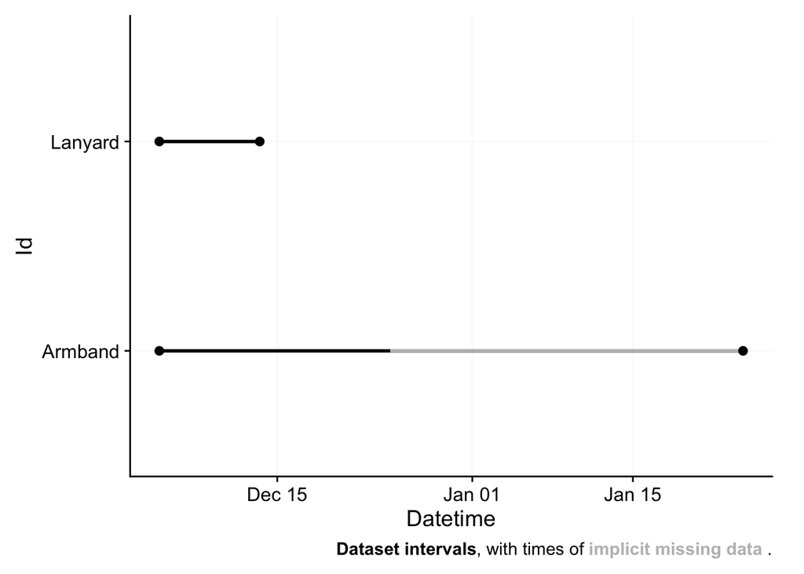

```r
ActLumus <- import$ActLumus(ActLumus_files, tz = tz, auto.id = "\\((.*)\\)")
```

### VEET

```
Multiple files in zip: reading 'Left_Temple_Sensor_Data.csv'
Multiple files in zip: reading 'Right_Temple_Sensor_Data.csv'
```

```
Successfully read in 275'979 observations across 2 Ids from 2 VEET-file(s).
Timezone set is Europe/Berlin.

First Observation: 2026-01-02 04:58:45
Last Observation: 2026-01-24 14:12:16
Data from before 2026-01-01 were not imported. Adjust with `not.before` if needed.
Timespan: 22 days

Observation intervals:
   Id          interval.time      n pct
 1 Left_Temple 1s              1428 1.03133%
 2 Left_Temple 2s            135188 97.63545%
 3 Left_Temple 3s              1586 1.14544%
 4 Left_Temple 4s               208 0.15022%
 5 Left_Temple 5s                11 0.00794%
 6 Left_Temple 6s                19 0.01372%
 7 Left_Temple 8s                 3 0.00217%
 8 Left_Temple 9s                 1 0.00072%
 9 Left_Temple 10s                5 0.00361%
10 Left_Temple 12s                1 0.00072%
# ℹ 28 more rows
```

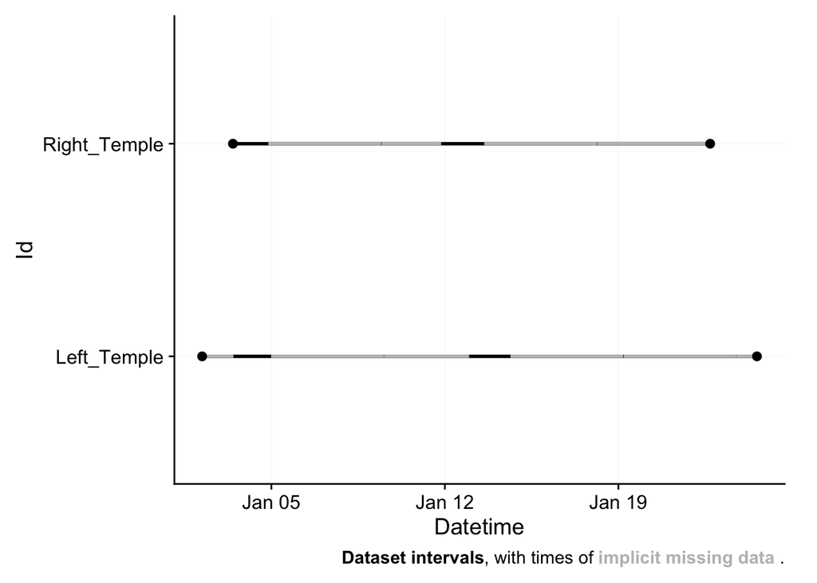

```r
VEET_light <-
  import$VEET(VEET_files,
              tz,
              auto.id = ".*_Temple",
              modality = "ALS",
              not.before = "2026-01-01"
              )
```

```
Multiple files in zip: reading 'Left_Temple_Sensor_Data.csv'
Multiple files in zip: reading 'Right_Temple_Sensor_Data.csv'
```

```
Successfully read in 276'578 observations across 2 Ids from 2 VEET-file(s).
Timezone set is Europe/Berlin.

First Observation: 2026-01-02 04:58:45
Last Observation: 2026-01-24 14:12:16
Data from before 2026-01-01 were not imported. Adjust with `not.before` if needed.
Timespan: 22 days

Observation intervals:
   Id          interval.time              n pct
 1 Left_Temple 1s                       102 0.07350%
 2 Left_Temple 2s                    138390 99.72401%
 3 Left_Temple 3s                       268 0.19312%
 4 Left_Temple 4s                         3 0.00216%
 5 Left_Temple 11s                        1 0.00072%
 6 Left_Temple 13s                        2 0.00144%
 7 Left_Temple 24s                        1 0.00072%
 8 Left_Temple 71108s (~19.75 hours)      1 0.00072%
 9 Left_Temple 108799s (~1.26 days)       1 0.00072%
10 Left_Temple 296661s (~3.43 days)       1 0.00072%
# ℹ 13 more rows
```

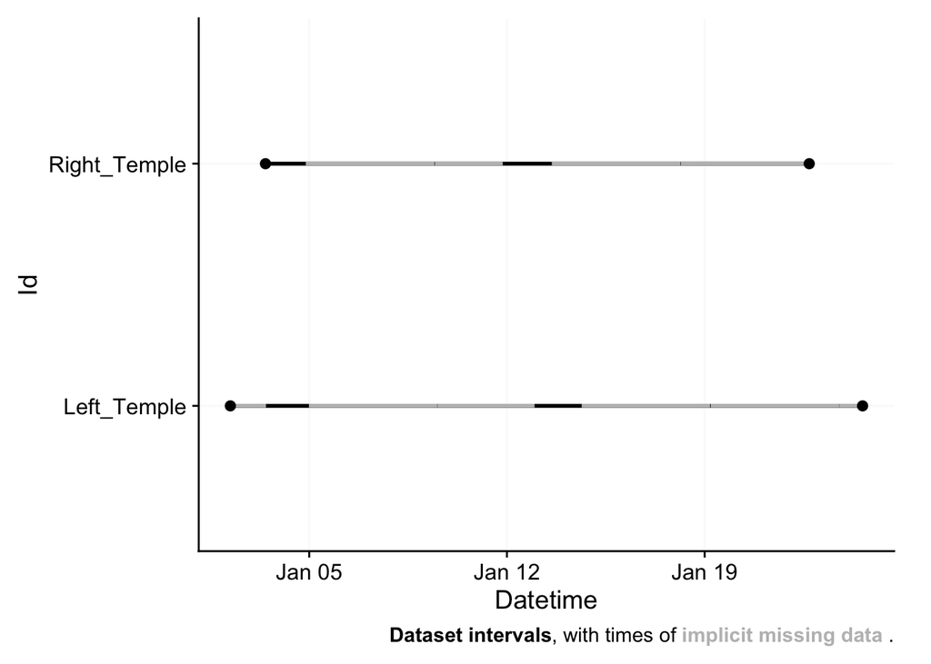

```r
VEET_activity <-
  import$VEET(VEET_files,
              tz,
              auto.id = ".*_Temple",
              modality = "IMU",
              not.before = "2026-01-01"
              )
```

## Cleaning/Preparation

### Logs

```r
#setting the date component of start to Date
date(Logs$start) <- date(Logs$Date)
dates <- date(Logs$Date) |> unique()

#convert from statechanges to states
Logs <-
  Logs |>
    select(-Date) |>
    sc2interval(start, wear, starting.state = "Off",
                length.restriction = Inf) |>
  select(-State)
```

### ActLumus

The `ActLumus` data will be skipped for now, as their recording times do not overlap with the `Logs` or the `VEET` data.

### VEET

#### Dataset overview

This section gives an overview of the `VEET_light` data.

```r
VEET_light |> summary_overview(Lux)
```

```
# A tibble: 4 × 4
  name                mean   min   max
  <chr>              <dbl> <dbl> <dbl>
1 Participants        2    NA    NA
2 Participant-days   18     8    10
3 Days ≥80% complete  0     0     0
4 Missing/Irregular   0.86  0.85  0.87
```

```r
VEET_light |> has_irregulars()
```

```
[1] TRUE
```

```r
VEET_light |> dominant_epoch()
```

```
# A tibble: 2 × 3
  Id           dominant.epoch group.indices
  <fct>        <Duration>             <int>
1 Left_Temple  2s                         1
2 Right_Temple 2s                         2
```

```r
VEET_light |> durations(Lux, show.interval = TRUE)
```

```
# A tibble: 2 × 3
# Groups:   Id [2]
  Id           duration             interval
  <fct>        <Duration>           <Duration>
1 Left_Temple  276926s (~3.21 days) 2s
2 Right_Temple 275032s (~3.18 days) 2s
```

The summaries show that the two VEET devices (`left temple` and `right temple`) cover quite some time but contain little data (86% of data is missing). The data is irregular (which the import summaries already indicated), and covers roughly 3.2 days of data, given a `2 second` measurement interval.

#### Adjusting time scales

`VEET` data are recorded somewhat irregularly. To get to a regular scale, we will aggregate the data to `10 second` bins. This will also reduce the data size while still being short enough to allow meaningful analysis of the variation. Repeating this step for the activity data has the nice benefit that time stamps align perfectly between the two sets.

> In case a higher resolution is needed, the `unit` argument can be adjusted at will.

```r
unit <- "10 secs"
VEET_light <- VEET_light |> aggregate_Datetime(unit)
VEET_activity <- VEET_activity |>  aggregate_Datetime(unit)
```

```r
VEET_light |> has_irregulars()
```

```
[1] FALSE
```

#### Join light and activity data

```r
VEET <-
  VEET_light |>
  left_join(VEET_activity,
            by = c("Id", "Datetime"),
            suffix = c(".light", ".activity"))
```

## Join wearable data with log data

This step adds the `Log` information to the wearable `VEET` data.

```r
VEET <-
  VEET |>
  ungroup() |> #ungrouping (and regrouping) is necessary, as the log data extends beyond the individual devices
  add_states(Logs,
             start.colname = Interval,
             end.colname = Interval,
             force.tz = TRUE
             ) |>
  group_by(Id)
```

#### Reduce data down to relevant days

We are only interested in times where we have log data. Thus, we will remove all times without a wear state.

```r
VEET <-
  VEET |>
  filter(!is.na(wear))
```

To remove implicit gaps on relevant days, we will fill those times in.

```r
VEET <-
  VEET |>
  add_Date_col(group.by = TRUE) |>
  filter(Date %in% dates) |>
  gap_handler(full.days = TRUE)
```

## Explorative descriptives

To get an overview of the resulting data, we create a few summaries and plots

```r
VEET |> summary_overview(Lux)
```

```
# A tibble: 4 × 4
  name                mean   min   max
  <chr>              <dbl> <dbl> <dbl>
1 Participants        2       NA NA
2 Participant-days    6        3  3
3 Days ≥80% complete  3        1  2
4 Missing/Irregular   0.34     0  0.98
```

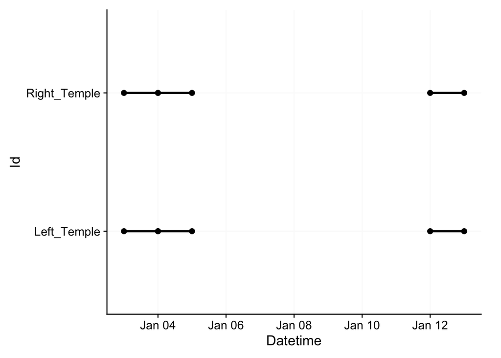

```r
VEET |> gg_overview()
```

```r
VEET |> gap_table(Lux) |> gt::cols_hide(contains("_n"))
```

Summary of available and missing data

Variable: melanopic EDI

|  | Data Regular Time | Data Regular % | Data Irregular n<sup>1,2</sup> | Data Range Time | Data Interval Time | Missing Gaps N | Missing Gaps ø | Missing Gaps Time | Missing Gaps % | Missing Implicit Time | Missing Implicit % | Missing Explicit Time | Missing Explicit % |
| --- | --- | --- | --- | --- | --- | --- | --- | --- | --- | --- | --- | --- | --- |
| **Overall** | 3d 23h 31m 30s | 66.2%<sup>3</sup> | 0 | 6d 14m | 10 | 8 | 1d 16h 2m 3s | 2d 42m 30s | 33.8%<sup>3</sup> | 0s | 0.0%<sup>3</sup> | 2d 42m 30s | 33.8%<sup>3</sup> |
| Left_Temple - 2026-01-03 |  |  |  |  |  |  |  |  |  |  |  |  |  |
|  | 12h 49m 10s | 53.3% | 0 | 1d 2m 10s | 10s | 1 | 11h 13m | 11h 13m | 46.7% | 0s | 0.0% | 11h 13m | 46.7% |
| Left_Temple - 2026-01-04 |  |  |  |  |  |  |  |  |  |  |  |  |  |
|  | 23h 47m 50s | 98.9% | 0 | 1d 3m 10s | 10s | 1 | 15m 20s | 15m 20s | 1.1% | 0s | 0.0% | 15m 20s | 1.1% |
| Left_Temple - 2026-01-12 |  |  |  |  |  |  |  |  |  |  |  |  |  |
|  | 30m 20s | 2.1% | 0 | 1d | 10s | 1 | 23h 29m 40s | 23h 29m 40s | 97.9% | 0s | 0.0% | 23h 29m 40s | 97.9% |
| Right_Temple - 2026-01-03 |  |  |  |  |  |  |  |  |  |  |  |  |  |
|  | 13h 13m | 55.0% | 0 | 1d 2m 10s | 10s | 3 | 3h 36m 23s | 10h 49m 10s | 45.0% | 0s | 0.0% | 10h 49m 10s | 45.0% |
| Right_Temple - 2026-01-04 |  |  |  |  |  |  |  |  |  |  |  |  |  |
|  | 21h 7m 30s | 87.8% | 0 | 1d 2m 50s | 10s | 2 | 1h 27m 40s | 2h 55m 20s | 12.2% | 0s | 0.0% | 2h 55m 20s | 12.2% |
| Right_Temple - 2026-01-12 |  |  |  |  |  |  |  |  |  |  |  |  |  |
|  | 1d 3m 40s | 100.0% | 0 | 1d 3m 40s | 10s | 0 | 0s | 0s | 0.0% | 0s | 0.0% | 0s | 0.0% |

<sup>1</sup> If n > 0: it is possible that the other summary statistics are affected, as they are calculated based on the most prominent interval.  
<sup>2</sup> Number of (missing or actual) observations  
<sup>3</sup> Based on times, not necessarily number of observations

```r
VEET |> durations(Lux, show.missing = TRUE) |> select(-total)
```

```
# A tibble: 6 × 4
# Groups:   Id, Date [6]
  Id           Date       duration               missing
  <fct>        <date>     <Duration>             <Duration>
1 Left_Temple  2026-01-03 46150s (~12.82 hours)  40380s (~11.22 hours)
2 Left_Temple  2026-01-04 85670s (~23.8 hours)   920s (~15.33 minutes)
3 Left_Temple  2026-01-12 1820s (~30.33 minutes) 84580s (~23.49 hours)
4 Right_Temple 2026-01-03 47580s (~13.22 hours)  38950s (~10.82 hours)
5 Right_Temple 2026-01-04 76050s (~21.12 hours)  10520s (~2.92 hours)
6 Right_Temple 2026-01-12 86620s (~1 days)       0s
```

```r
VEET |>
  group_by(wear, .add = TRUE) |>
  durations(Lux, show.missing = TRUE) |>
  group_by(Id) |>
  gt::gt()
```

| Date | wear | duration | missing | total |
| --- | --- | --- | --- | --- |
| Left_Temple |  |  |  |  |
| 2026-01-03 | Off | 22270s (~6.19 hours) | 0s | 22270s (~6.19 hours) |
| 2026-01-03 | On | 23880s (~6.63 hours) | 0s | 23880s (~6.63 hours) |
| 2026-01-03 | NA | 0s | 40380s (~11.22 hours) | 40380s (~11.22 hours) |
| 2026-01-04 | Off | 58510s (~16.25 hours) | 0s | 58510s (~16.25 hours) |
| 2026-01-04 | On | 27160s (~7.54 hours) | 0s | 27160s (~7.54 hours) |
| 2026-01-04 | NA | 0s | 920s (~15.33 minutes) | 920s (~15.33 minutes) |
| 2026-01-12 | Off | 1820s (~30.33 minutes) | 0s | 1820s (~30.33 minutes) |
| 2026-01-12 | NA | 0s | 84580s (~23.49 hours) | 84580s (~23.49 hours) |
| Right_Temple |  |  |  |  |
| 2026-01-03 | Off | 23700s (~6.58 hours) | 0s | 23700s (~6.58 hours) |
| 2026-01-03 | On | 23880s (~6.63 hours) | 0s | 23880s (~6.63 hours) |
| 2026-01-03 | NA | 0s | 38950s (~10.82 hours) | 38950s (~10.82 hours) |
| 2026-01-04 | Off | 51210s (~14.22 hours) | 0s | 51210s (~14.22 hours) |
| 2026-01-04 | On | 24840s (~6.9 hours) | 0s | 24840s (~6.9 hours) |
| 2026-01-04 | NA | 0s | 10520s (~2.92 hours) | 10520s (~2.92 hours) |
| 2026-01-12 | Off | 48080s (~13.36 hours) | 0s | 48080s (~13.36 hours) |
| 2026-01-12 | On | 38540s (~10.71 hours) | 0s | 38540s (~10.71 hours) |

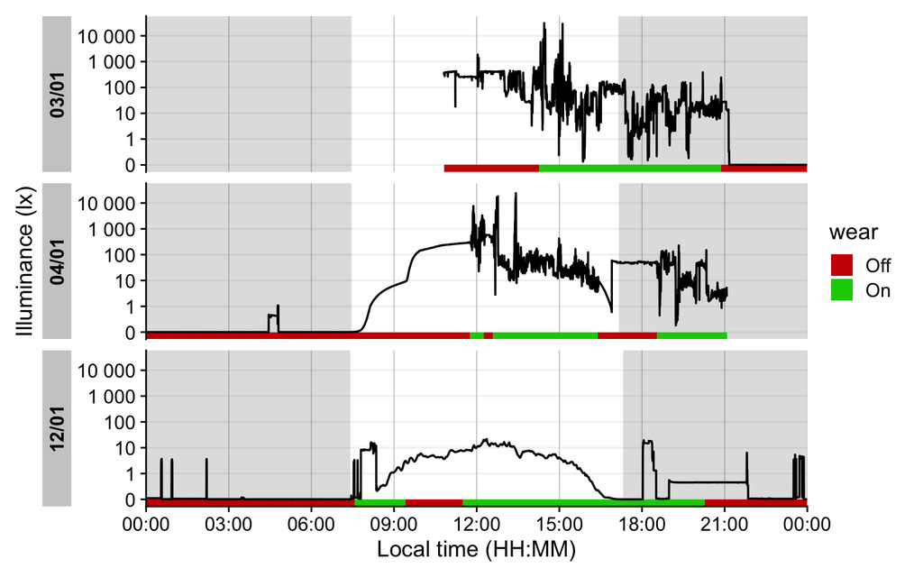

```r
VEET |>
  group_by(Id) |>
  sample_groups(sample = 2) |> #set to 1 or two to get individual samples
  gg_day(Lux, geom = "line", group = Id, y.axis.label = "Illuminance (lx)") |>
  gg_states(wear, aes_fill = wear, ymax = 0, alpha = 1) |>
  gg_photoperiod(coordinates) +
  ggplot2::scale_fill_manual(values=c("red3", "green3"))
```

## Export

```r
path <- paste0(here("data", "cleaned"),"/wear_data_cleaned.RData")
save(VEET, file = path)
```